# Sample Project

### Purpose of Project

We are here to help give you some insight into what we do as part of our jobs as statisticians and actuaries. Many of the topics discussed in this class we use regularly in our work. To help solidify some of the things you will learn in your AP Stats curriculum, we are going to go through a real world dataset to analyze and draw conculsions on. We will spend a majority of the rest of the school year going through how to do the analysis with the final month or two having you do the same analysis on a different dataset we provide. This will all end with a presentation on what you have learned at the end of the year.

### R Studio

To do the analysis on your dataset, we will be using a free statisticial software called R Studio. If you haven’t downloaded R Studio yet, let us know and we can help you get it downloaded.

The parts of R Studio that we will be using are discussed below:

[figure not shown]

#### R Script

The R Script is where we will be copying and pasting your code to run. To open up a new R Script, click on the drop down arrow under File and click on R Script.

[figure not shown]

#### Running Folder Setup Code

Let’s start by putting some code into the R Script. The following code will produce two folders on your desktop after it’s run. state_farm_project_demo is where we will be saving files related to the analysis we do together in class. state_farm_project is where you will be saving files related to your end of year project. Make sure to not delete these folders in the months to come. Copy and paste this piece of code into your R Script:

```r
## Step 0: Creating folders on your desktop ##
install.packages("svDialogs")
library("svDialogs")
set_up_directories <- function(){
  # Change this to the directory path that leads up to the alias
  base_directory <- "C:/Users/"
  # Print out all child folders of "base_directory". One of them should be their alias.
  get_alias <- function(){dlg_list(list.files(base_directory), multiple = FALSE, title = "\n\nSelect which one is your alias...\nType the number that corresponds and then hit enter...\n\n" ,gui = .GUI)$res}
  alias <- get_alias()
  # Create path for new folder to be created
  path <- paste(base_directory,alias,"/Desktop/state_farm_project",sep="")
  dir.create(path = path, showWarnings = FALSE)
  dir.create(path = paste(path,"_demo",sep=""), showWarnings = FALSE)
  exist <- file.exists(paste(path,"_demo/STEM_Project_For_",alias,".R",sep=""))
  if(!exist){
    download.file("https://raw.githubusercontent.com/tmthiel2/STEM/master/testing.R",destfile = paste(path,"_demo/STEM_Project_For_",alias,".R",sep=""))
  }
  cat("\n\nYou should now have two new folders on your desktop named the following:\n\tstate_farm_project\n\tstate_farm_project_demo\n\nIf you do not see these folders on your desktop, run the code again and be sure to type the number that corresponds to your alias. If the folders still aren't being created, ask a State Farm person for help.")
}
set_up_directories()
```

#### Console

The console is where the code we wrote in the R Script will actually be run.

Let’s practice! Highlight all the code in Step 0 above and click on Run at the top right of your R Script. When it prompts you for Selection, type in the number corresponding to your name/alias from the list. Make sure that the two folders are created on your desktop. Close the R Script without saving it. Go into the state_farm_project_demo folder and open up the R file that starts with STEM_Project_For_XXXXX. This will be the R Script we use to save all your code throughout the rest of the year.

#### Environment

The environment is where our dataset will be stored once we read it in.

#### Plots

The plots section is exactly like it sounds. When we produce plots later on in our analysis, you will see them show up here.

#### Packages

R Studio is not built with all the tools we need for analysis, however, many packages are available for install to help us with the analysis we plan to do. This section will list all the packages you have already installed on your machine.

Let’s practice! We are going to install the ggplot2 package. Copy and paste this piece of code to your R Script, highlight both lines, and run it.

```r
## Step 1: Practice installation of a package ##
install.packages("ggplot2")
library("ggplot2")
```

### What is a Dataset?

A dataset is a collection of data usually presented in tabular (table) form. Each dataset is made up of both rows and columns and contains information regarding a specific subject matter.

The dataset will look something like this:

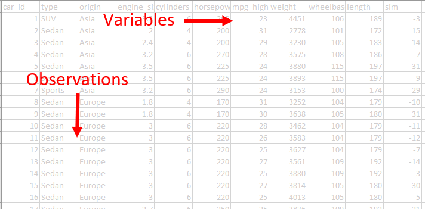

#### Observations (Rows)

A dataset contains many observations which are represented by rows in the table. Examples of observations (rows) in a dataset could be:

- People
- Games
- Houses
- Cars

#### Variables (Columns)

A dataset contains many variables which are represented by columns in the table. Each column corresponds to a specific piece of information regarding that observation. Examples of variables (columns) could be:

- Age of the person
- Sales of the video game
- Price of the house
- Weight of the car

#### Types of Variables

There are many different types of variables that we will be working with:

- Identification Variables: Variables that are used to identify results - a single value for every observations.
  - Examples: Social Security Number, Employee ID Number, Observation Number
- Continuous Variables: Variables that can have an infinite number of values.
  - Examples: Weight, Price, Time
- Categorical Variables: Variables that have values that can be grouped into categories.
  - Nominal: 2 or more categories but no order (Examples: Types of property, States)
  - Binary: Only 2 categories (Examples: Male/Female, Yes/No, 0/1)
  - Ordinal: 2 or more categories that have an order (Examples: Low/Medium/High, Poor/Average/Good)

#### Target & Predictor Variables

We also want to identify our target (dependent) variable and predictor (independent) variables. Our target variable is the thing we are trying to predict, while our predictor variables are the variables we are using to predict the target.

### About Your Dataset

With the dataset we will be working through in class, we will be predicting highway miles per gallon based on other car characteristics.

Copy and paste the following code into the your R Script to read the dataset into R:

```r
## Step 2: Reading your dataset into R ##
install.packages("readr")
library("readr")
urlfile <- "https://github.com/tmthiel2/STEM/raw/master/Example Data.csv"
All_Data<-as.data.frame(read_csv(url(urlfile)))
```

#### Metadata

Here are the descriptions of the variables in the dataset:

| Variable | Description | Type of Variable | Predictor or Target |
| --- | --- | --- | --- |
| car_id | ID # of the car | Identification | Neither - don’t use id in model |
| engine_size | Engine size of the car | Continuous | Predictor |
| cylinders | Number of cylinders in the car | Continuous | Predictor |
| horsepower | Horsepower of the car | Continuous | Predictor |
| mpg_highway | Highway miles per gallon the car gets | Continuous | Target |
| weight | Weight of the car | Continuous | Predictor |
| wheelbase | Wheelbase on the car | Continuous | Predictor |
| length | Length of the car | Continuous | Predictor |
| car | Is it a car? | Categorical - Binary | Predictor |
| suv | Is it an SUV? | Categorical - Binary | Predictor |
| from_asia | Is the car from Asia? | Categorical - Binary | Predictor |
| from_europe | Is the car from Europe? | Categorical - Binary | Predictor |
| from_usa | Is the car from the USA? | Categorical - Binary | Predictor |
| sim | Random variable | Continuous | Predictor |

#### How many observations are in your dataset?

Copy and paste the following code into your R Script and run it to count the number of observations in your dataset:

```r
## Step 3: Calculating the number of rows in your dataset ##
num_obs <- nrow(All_Data)
num_obs
```

```
[1] 428
```

Copy and paste the following comment into your R Script to keep track of your answers:

```r
## Step 4: How many observations are in your dataset? ##

## There are 428 observations in the dataset.         ##
```

#### How many variables are in your dataset?

Copy and paste the following code into your R Script and run it to count the number of variables in your dataset:

```r
## Step 5: Calculating the number of columns in your dataset ##
num_col <- ncol(All_Data)
num_col
```

```
[1] 14
```

Copy and paste the following comment into your R Script to keep track of your answers:

```r
## Step 6: How many variables are in your dataset? ##

## There are 14 variables in the dataset.          ##
```

### What is a Predictive Model?

As part of the analysis we will be performing on your dataset, we will be building something called a predictive model. A predictive model is taking a bunch of variables and data about a certain subject and predicting outcomes based on that data. Some examples include:

- Predicting the sales of iPhones based on customer characteristics
- Predicting if a customer is likely to cancel Netflix or not based on viewer characteristics
- Predicting the price of a car based on economic chracteristics
- Predicting the number of Super Bowl viewers based on the American public characteristics
- Predicting if an email is spam or not based on word characteristics

A very simple predictive model is a model with one variable. This may be more familiar to you if we write it out in formula form:
$$y = mx + b$$

In statistics, we write this same formula as:
$$y = \beta_1x_1 + \beta_0$$
In this formula, $\beta_o$ is the y-intercept just as $b$ is above. $\beta_1$ is the slope of the line just as $m$ is in the above formula.

Now, let’s say we want to predict someone’s weight based on their height (a one variable predictive model). We have plotted out the observations we have in our data as shown below:

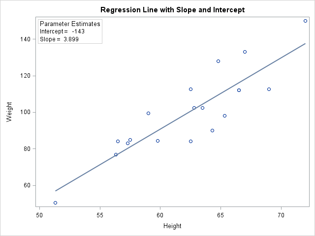

We have fit a predictive model to the data (straight line) and we know the parameter estimates (slope & y-intercept) as well. We can write out this predictive model as:
$$Predicted Weight = 3.899(height) + (-143)$$

We can now use this formula to predict other observations that weren’t in our dataset. Some examples:

- Height of 5 ft person (60 inches): 90.94 lbs
- Height of 5 1/2 ft person (66 inches): 114.334 lbs
- Height of 6 ft person (72 inches): 137.728 lbs
- Height of 6 1/2 ft person (78 inches): 161.122 lbs

DISCLAIMER: This is fake data from the internet.

If we have more than one variable in our predictive model, we continue to add $\beta_n$ terms to the model such as this:
$$y = \beta_1x_1 + \beta_2x_2 + \beta_3x_3 + ... + \beta_nx_n + \beta_0$$

This is further discussed below in the interpretation section.

### Partition Data

When building a predictive model, we build the model on only part of the dataset. This is know as the Training Data. We typically use 60-70% of the entire dataset as the Training Data. That leaves 30-40% of the dataset remaining for us to test our predictive model on. We call this our Validation Data.

As an example of this concept, let’s say we wanted to predict the sale of yearbooks at BHS. We have information about every high school student and after splitting the dataset, we will use the training data to build this model. We can then test our model on the remaining students (validation) data. An important part of statistics and this type of analysis is to calculate how accurate your model was in predicting. In this example, we know what our model predicted for yearbook sales of the students in the validation data. But, we also know what the real sales were and can calculate how much error our model produced.

#### Create Training & Validation Data

Let’s split your dataset into training and validation data. Copy and paste the following code into your R Script and run it.

```r
## Step 7: Splitting your dataset into 60% training and 40% validation ##
set.seed(10)
p60 <- quantile(All_Data$sim,0.6)
Training_Data <- All_Data[which(All_Data$sim <= p60),]
Validation_Data <- All_Data[which(All_Data$sim > p60),]
```

### EDA

Before we start model building, it’s important to do Exploratory Data Analysis (EDA). EDA helps us look at the relationships in the data before we start modeling. It may reveal patterns that we didn’t know existed before and could help with our interpretation of the model later. EDA can involve things such as:

- Deciles - How spread out are the values in each variable?
- Frequencies - For the categorical variables, do the levels of those variables make sense and are there adequate number of observations in each level?
- Plots - Are there patterns in the data that we don’t expect?
- Correlations - How correlated are the variables in our dataset?

#### Deciles (Continuous Variables)

The first set of EDA we are going to perform is to look at the deciles of the continuous variables. Deciles divide the continuous variable up into 10 equal parts and display the value at every 10% of observations. As an example:

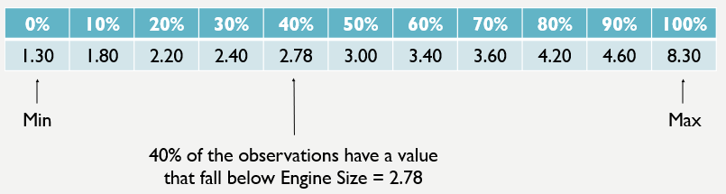

Copy and paste the following code into your R Script and run all of your deciles.

```r
## Step 8: Run out the deciles to see the distributions of each numeric variable ##
Deciles_enginesize <- quantile(All_Data$engine_size, probs = seq(0, 1,length=11))
Deciles_enginesize
```

```
  0%  10%  20%  30%  40%  50%  60%  70%  80%  90% 100%
1.30 1.80 2.20 2.40 2.78 3.00 3.40 3.60 4.20 4.60 8.30
```

```r
Deciles_cylinders <- quantile(All_Data$cylinders, probs = seq(0, 1,length=11))
Deciles_cylinders
```

```
  0%  10%  20%  30%  40%  50%  60%  70%  80%  90% 100%
   4    4    4    4    6    6    6    6    8    8    8
```

```r
Deciles_horsepower <- quantile(All_Data$horsepower, probs = seq(0, 1,length=11))
Deciles_horsepower
```

```
   0%   10%   20%   30%   40%   50%   60%   70%   80%   90%  100%
 73.0 130.0 155.0 170.2 192.8 210.0 224.0 240.0 275.0 302.0 500.0
```

```r
Deciles_mpghighway <- quantile(All_Data$mpg_highway, probs = seq(0, 1,length=11))
Deciles_mpghighway
```

```
  0%  10%  20%  30%  40%  50%  60%  70%  80%  90% 100%
12.0 20.0 23.0 25.0 26.0 26.0 28.0 29.0 30.0 33.3 66.0
```

```r
Deciles_weight <- quantile(All_Data$weight, probs = seq(0, 1,length=11))
Deciles_weight
```

```
    0%    10%    20%    30%    40%    50%    60%    70%    80%    90%   100%
1850.0 2678.7 2995.6 3217.0 3351.0 3476.0 3649.2 3836.0 4057.0 4543.8 7190.0
```

```r
Deciles_wheelbase <- quantile(All_Data$wheelbase, probs = seq(0, 1,length=11))
Deciles_wheelbase
```

```
  0%  10%  20%  30%  40%  50%  60%  70%  80%  90% 100%
  89   99  102  104  106  107  109  111  114  119  144
```

```r
Deciles_length <- quantile(All_Data$length, probs = seq(0, 1,length=11))
Deciles_length
```

```
  0%  10%  20%  30%  40%  50%  60%  70%  80%  90% 100%
 143  168  176  178  183  187  190  192  198  204  238
```

```r
Deciles_sim <- quantile(All_Data$sim, probs = seq(0, 1,length=11))
Deciles_sim
```

```
    0%    10%    20%    30%    40%    50%    60%    70%    80%    90%   100%
0.0010 0.0936 0.1836 0.2851 0.3630 0.4410 0.5780 0.6718 0.7870 0.9146 0.9940
```

Copy and paste the following comment into your R Script to keep track of your answers:

```r
## Step 9: Do all the deciles look reasonable? ##

## All the deciles look reasonable.            ##
```

#### Frequencies (Categorical Variables)

For the categorical variables, we can’t calculate deciles so instead we look at the number of observations that fall into each level of the variable. This is called calculating frequencies. When calculating frequencies, we are looking to see that all the levels make sense for the variable as well as that there are a sufficient number of observations in each level.

Copy, paste, and run the code below to calculate the frequencies:

```r
## Step 10: Calculating the frequencies on categorical variables ##
Car_Freq <- table(All_Data$car)
Car_Freq
```

```
 No Yes
 84 344
```

```r
SUV_Freq <- table(All_Data$suv)
SUV_Freq
```

```
 No Yes
344  84
```

```r
Asia_Freq <- table(All_Data$from_asia)
Asia_Freq
```

```
 No Yes
270 158
```

```r
Europe_Freq <- table(All_Data$from_europe)
Europe_Freq
```

```
 No Yes
305 123
```

```r
USA_Freq <- table(All_Data$from_usa)
USA_Freq
```

```
 No Yes
281 147
```

Copy and paste the following comment into your R Script to keep track of your answers:

```r
## Step 11: Do all of the variables appear to have sufficient number of observations in each level?

## Yes all the variables seem to have a sufficient number of obs in each level.
```

#### Plotting Variables

For the continuous numeric variables, we are going to use scatterplots to look at the relationship between each predictor variable and the target variable.

Copy, paste, and run the following code:

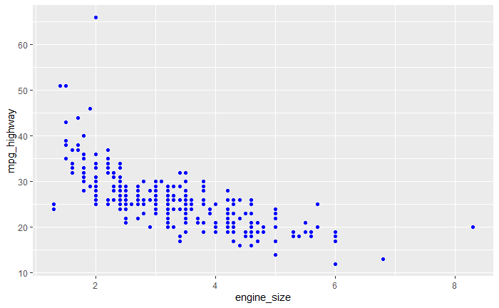

```r
## Step 12: Plotting the numeric variables ##
ggplot(data = All_Data) + geom_point(aes(x = engine_size, y = mpg_highway), colour = 'blue')
```

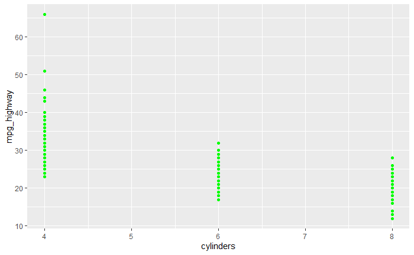

```r
ggplot(data = All_Data) + geom_point(aes(x = cylinders, y = mpg_highway), colour = 'green')
```

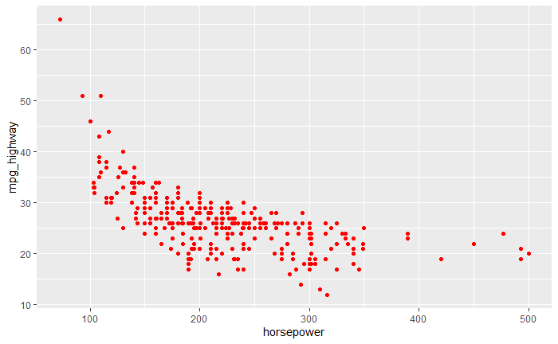

```r
ggplot(data = All_Data) + geom_point(aes(x = horsepower, y = mpg_highway), colour = 'red')
```

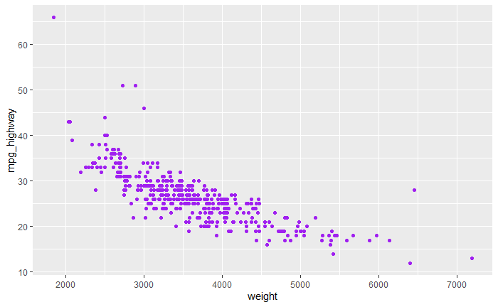

```r
ggplot(data = All_Data) + geom_point(aes(x = weight, y = mpg_highway), colour = 'purple')
```

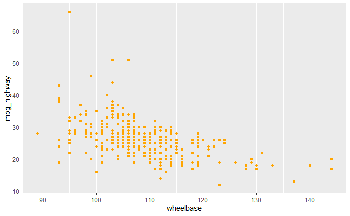

```r
ggplot(data = All_Data) + geom_point(aes(x = wheelbase, y = mpg_highway), colour = 'orange')
```

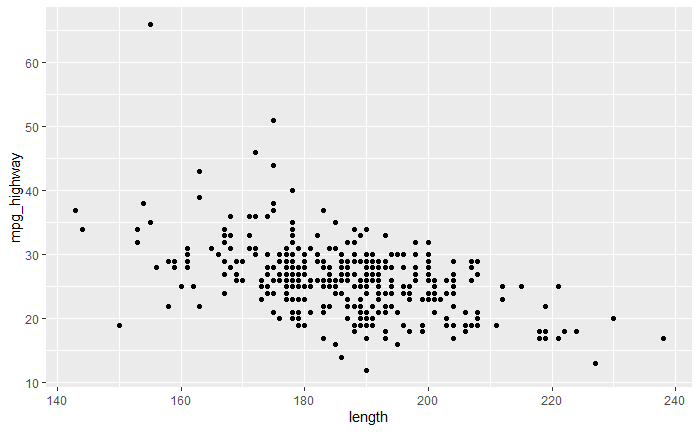

```r
ggplot(data = All_Data) + geom_point(aes(x = length, y = mpg_highway), colour = 'black')
```

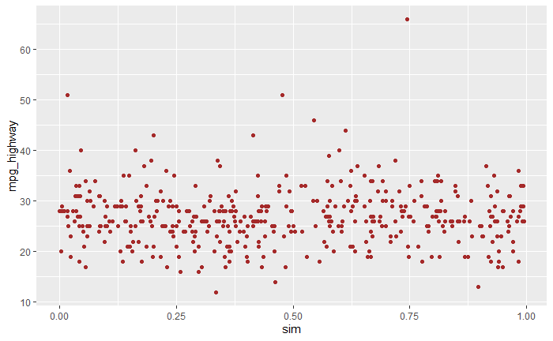

```r
ggplot(data = All_Data) + geom_point(aes(x = sim, y = mpg_highway), colour = 'brown')
```

Copy and paste the following comment into your R Script to keep track of your answers:

```r
## Step 13: Do the plots reveal any interesting patterns?  ##

## Engine Size seems to have a negative linear relationship with highway mpg            ##
## Cylinders - ehhh maybe linear?                                                       ##
## Horsepower seems to have a negative linear relationship with highway mpg             ##
## Weight seems to have a negative linear relationship with highway mpg                 ##
## Wheelbase, length, and sim don't seem to have a strong relationship with highway mpg ##
```

Next, let’s plot our categorical variables. We will use box and whisker plots to do this.

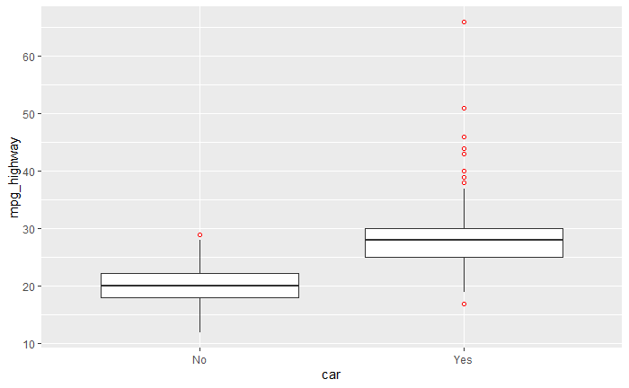

```r
## Step 14: Plotting the categorical variables ##
car <- ggplot(All_Data, aes(car, mpg_highway))
car + geom_boxplot(outlier.colour = "red", outlier.shape = 1)
```

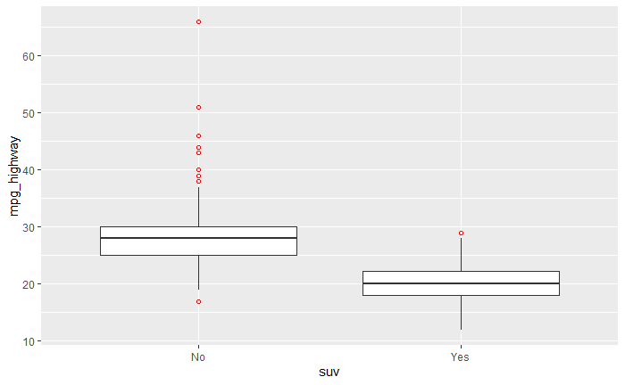

```r
suv <- ggplot(All_Data, aes(suv, mpg_highway))
suv + geom_boxplot(outlier.colour = "red", outlier.shape = 1)
```

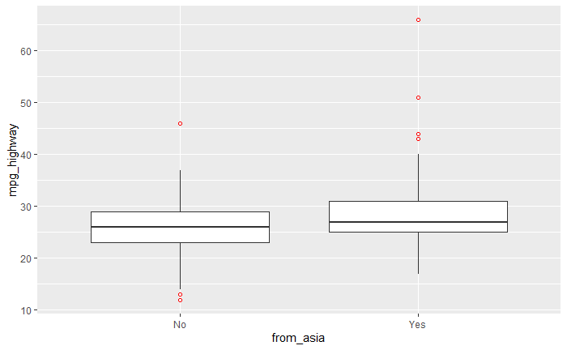

```r
asia <- ggplot(All_Data, aes(from_asia, mpg_highway))
asia + geom_boxplot(outlier.colour = "red", outlier.shape = 1)
```

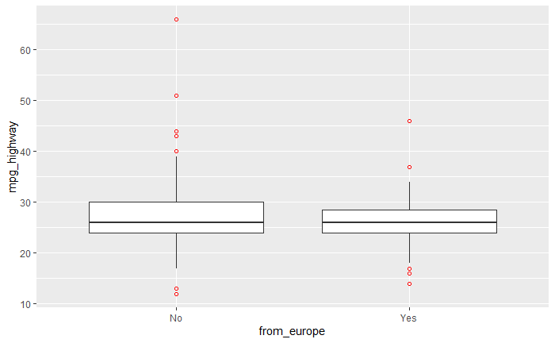

```r
europe <- ggplot(All_Data, aes(from_europe, mpg_highway))
europe + geom_boxplot(outlier.colour = "red", outlier.shape = 1)
```

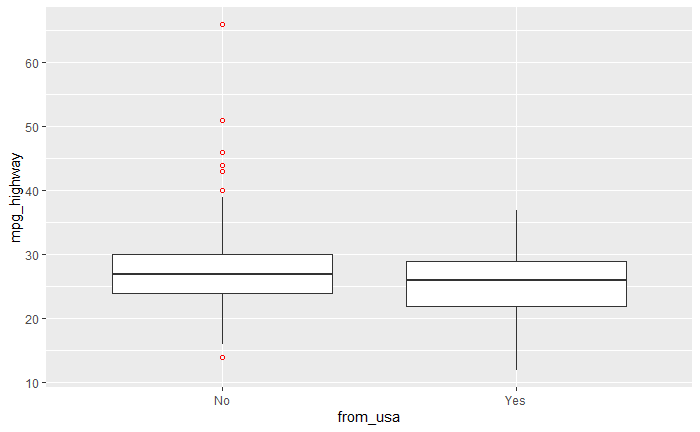

```r
usa <- ggplot(All_Data, aes(from_usa, mpg_highway))
usa + geom_boxplot(outlier.colour = "red", outlier.shape = 1)
```

The red points in these box and whisker plots indicate potential outlier points. It’s important to not automatically delete them, but rather look into those points to make sure the values make sense. In our case, even though we have quite a few potential outlier points, we aren’t going to delete any of them as none of them seem to have extreme values compared to the main set of values.

#### Correlations

Correlation is a measure of how strongly pairs of variables are related to each other. A correlation can range between -1 and +1 with -1 meaning perfect negative correlation, 0 meaning no correlation, and + 1 meaning perfect positive correlation. A perfect positive or negative correlation would result in a straight line between variables. Here are a few examples:

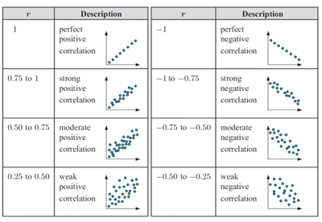

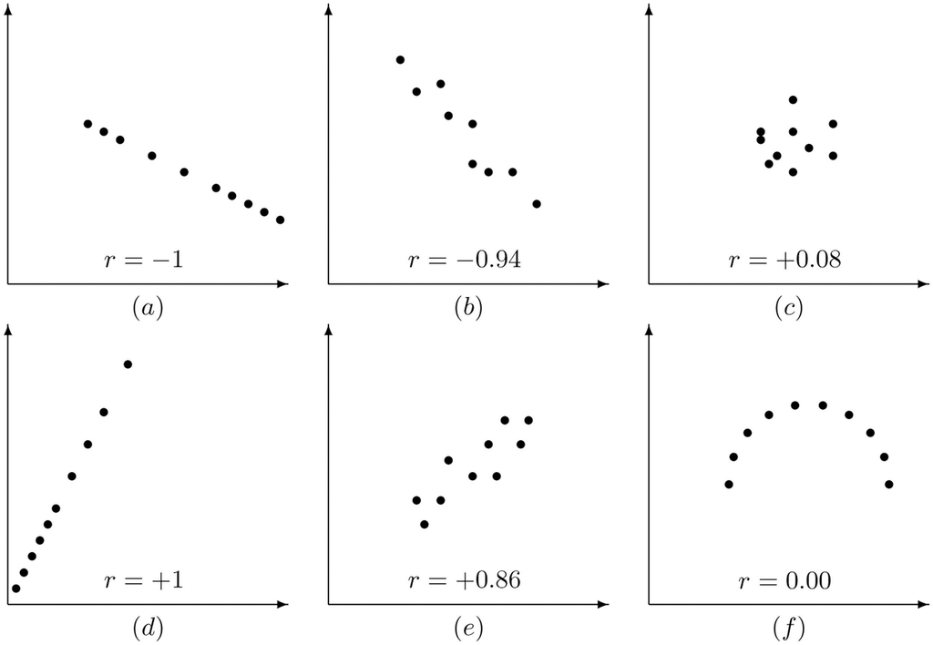

Let’s play a quick game of guess the correlation! http://www.rossmanchance.com/applets/GuessCorrelation.html

Copy, paste, and run the code to calculate the correlations in your dataset:

```r
## Step 15: Calculate correlations ##
Vars_Num <- c("engine_size", "cylinders", "horsepower", "mpg_highway", "weight", "wheelbase", "length", "sim")
Numeric_Data <- Training_Data[Vars_Num]
Correlation <- round(cor(Numeric_Data, method = c("pearson")),2)
Correlation
```

```
            engine_size cylinders horsepower mpg_highway weight wheelbase length   sim
engine_size        1.00      0.88       0.77       -0.73   0.76      0.60   0.59  0.09
cylinders          0.88      1.00       0.76       -0.67   0.72      0.54   0.54  0.10
horsepower         0.77      0.76       1.00       -0.63   0.57      0.33   0.30  0.04
mpg_highway       -0.73     -0.67      -0.63        1.00  -0.76     -0.51  -0.44 -0.06
weight             0.76      0.72       0.57       -0.76   1.00      0.70   0.62  0.12
wheelbase          0.60      0.54       0.33       -0.51   0.70      1.00   0.89  0.08
length             0.59      0.54       0.30       -0.44   0.62      0.89   1.00  0.08
sim                0.09      0.10       0.04       -0.06   0.12      0.08   0.08  1.00
```

We want to avoid having too many variables that are highly correlated in our model because it could affect interpretation. We may need to use our judgment to remove some variables out of the model if they are highly correlated with other modeling variables which can cause issues with the model. Correlations with the target variable on the other hand shows promise of a good predictive variable.

Copy and paste the following comment into your R Script to keep track of your answers:

```r
## Step 16: Are there variables in the dataset that we should watch out for? ##

## We see a pretty strong correlation between cylinders & engine_size and length & wheelbase. If we look at the correlations just between the target variable and the other variables, we might expect weight and engine_size in the model because they have really strong negative correlations. Let's see if that comes true when we build the model.
```

### Variable Selection

Our datasets can contain hundreds if not thousands of variables for each observation. We never want to use all the variables to model with for these reasons:

- Many of the variables will be correlated. As discussed in the last section, correlated variables can mess up our interpretation of the model.
- Risk of overfitting. When we build a model with too many variables, we may risk fitting our model (the line) perfectly through our training dataset. But, then we go to validate our model and we calculate a huge error because the model is perfectly built for the training data, but not for any other dataset. It doesn’t generalize well.
- Difficult to interpret. If there are too many variables in our model, it can be very difficult to interpret them and make sense of your model.

To help us narrow down the variables that should make it into our model, we use something called variable selection. We will look at one type when building our model - forward selection.

#### Forward Selection

With this technique, we start with no variables in the model and add variables to the model one at a time. At each step, each variable that is not already in the model is tested for inclusion in the model. The most significant of these variables (based on a certain criteria) is added to the model, so long as the variable meets the criteria significance you have set.

In this case, we are going to perform forward selection based on the AIC criteria. Copy, paste, and run the following code to perform forward selection for your data:

```r
## Step 17: Fitting a model using forward selection ##
null = lm(mpg_highway~1, data=Training_Data)


full = lm(mpg_highway~engine_size + cylinders + horsepower + weight + wheelbase + length + factor(car) + factor(suv) + factor(from_asia) + factor(from_europe) + factor(from_usa) + sim,data=Training_Data)


Fit_Forward = step(null, scope=list(lower=null, upper=full), direction="forward")
```

```
Start:  AIC=893.16
mpg_highway ~ 1

                      Df Sum of Sq    RSS    AIC
+ weight               1    4739.1 3421.3 670.88
+ engine_size          1    4359.7 3800.7 698.02
+ cylinders            1    3698.2 4462.2 739.41
+ horsepower           1    3226.6 4933.8 765.34
+ factor(car)          1    2386.4 5774.0 805.90
+ factor(suv)          1    2386.4 5774.0 805.90
+ wheelbase            1    2137.0 6023.4 816.82
+ length               1    1558.1 6602.3 840.49
+ factor(from_asia)    1     314.8 7845.6 885.01
+ factor(from_usa)     1     124.2 8036.2 891.20
<none>                             8160.4 893.16
+ factor(from_europe)  1      56.1 8104.3 893.37
+ sim                  1      29.2 8131.2 894.23

Step:  AIC=670.88
mpg_highway ~ weight

                      Df Sum of Sq    RSS    AIC
+ horsepower           1    457.38 2963.9 635.86
+ engine_size          1    453.32 2968.0 636.21
+ cylinders            1    274.33 3147.0 651.32
+ factor(car)          1    250.13 3171.2 653.30
+ factor(suv)          1    250.13 3171.2 653.30
<none>                             3421.3 670.88
+ length               1     13.66 3407.7 671.85
+ wheelbase            1      7.92 3413.4 672.29
+ sim                  1      6.53 3414.8 672.39
+ factor(from_usa)     1      1.03 3420.3 672.81
+ factor(from_europe)  1      0.30 3421.0 672.86
+ factor(from_asia)    1      0.23 3421.1 672.87

Step:  AIC=635.86
mpg_highway ~ weight + horsepower

                      Df Sum of Sq    RSS    AIC
+ factor(car)          1    526.48 2437.5 587.41
```

[output cut: 22 more lines]

```
+ length               1     0.284 2437.2 589.38
+ wheelbase            1     0.001 2437.5 589.41

Step:  AIC=583.78
mpg_highway ~ weight + horsepower + factor(car) + engine_size

                      Df Sum of Sq    RSS    AIC
<none>                             2384.9 583.78
+ cylinders            1    7.1712 2377.8 585.01
+ length               1    6.8071 2378.1 585.05
+ sim                  1    6.3620 2378.6 585.09
+ wheelbase            1    4.9200 2380.0 585.25
+ factor(from_europe)  1    0.0735 2384.9 585.78
+ factor(from_usa)     1    0.0422 2384.9 585.78
+ factor(from_asia)    1    0.0023 2384.9 585.78
```

Copy and paste the following comment into your R Script to keep track of your answers:

```r
## Step 18: How many variables are chosen in the final step of forward selection? ##

## There are 4 variables chosen in forward selection: weight, horsepower, factor(car), engine_size.
```

### Fitting Final Regression Model

We are going to fit our final regression model using the results from forward selection.

Copy, paste, and run the following code to fit your model:

```r
## Step 19: Fitting the final regression model ##
options(digits=3)
Final_Model <- lm(mpg_highway ~ weight + horsepower + factor(car) + engine_size, data=Training_Data)
summary(Final_Model)
```

```
Call:
lm(formula = mpg_highway ~ weight + horsepower + factor(car) +
    engine_size, data = Training_Data)

Residuals:
   Min     1Q Median     3Q    Max
-7.838 -1.737 -0.183  1.660 18.015

Coefficients:
                Estimate Std. Error t value Pr(>|t|)
(Intercept)    39.336603   1.386029   28.38  < 2e-16 ***
weight         -0.002358   0.000424   -5.56  7.0e-08 ***
horsepower     -0.022803   0.004301   -5.30  2.5e-07 ***
factor(car)Yes  4.190985   0.588061    7.13  1.1e-11 ***
engine_size    -0.814026   0.344825   -2.36    0.019 *
---
Signif. codes:  0 ‘***’ 0.001 ‘**’ 0.01 ‘*’ 0.05 ‘.’ 0.1 ‘ ’ 1

Residual standard error: 3.07 on 253 degrees of freedom
Multiple R-squared:  0.708, Adjusted R-squared:  0.703
F-statistic:  153 on 4 and 253 DF,  p-value: <2e-16
```

### Validate the Model

Now that we have our final regression model built, we want to test it with our validation data to see how well it generalizes. Copy, paste, and run the following code to fit your model:

```r
## Step 20: Validating the Model ##
val_predict <- predict(Final_Model,Validation_Data)
Validation_Predictions <- cbind(Validation_Data,val_predict)
```

### Model Performance

#### MAPE

Mean Absolute Percentage Error (MAPE) is a measure of prediction accuracy. It is defined as:

$$MAPE=\frac{1}{n} \sum_{t=1}^n \left\lvert{\frac{Actual_t - Predicted_t}{Actual_t}}\right\rvert * 100$$
where: n = # of observations (in this case in our validation data) and t = observation #.

#### MAPE for Predictions from Your Predictive Model

Copy, paste, and run the following code to calculate the MAPE for your predictive model against the validation data:

```r
## Step 21: Calculating MAPE from your predictive model ##
count_obs_val <- nrow(Validation_Predictions)
Inside_val <- abs((Validation_Predictions$mpg_highway - Validation_Predictions$val_predict)/Validation_Predictions$mpg_highway)
MAPE_val <- ((1/count_obs_val)*sum(Inside_val))*100
MAPE_val
```

```
[1] 7.49
```

Copy and paste the following comment into your R Script to keep track of your answers:

```r
## Step 22: What is the MAPE value your model produced? ##

## 7.49% ##
```

#### MAPE for Mean Predictions

Another way to make predictions without building a predictive model is to use the mean of the target value as the new predictions. Let’s calculate the MAPE on this “model” and see how much better our MAPE is when we built a model vs just using the mean:

```r
## Step 23: Calculating MAPE for mean predictions ##
mpg_highway_mean <- mean(Training_Data$mpg_highway)
Validation_Data_Mean <- cbind(Validation_Data,mpg_highway_mean)

count_obs_val_mean <- nrow(Validation_Data_Mean)
Inside_val_mean <- abs((Validation_Data_Mean$mpg_highway - Validation_Data_Mean$mpg_highway_mean)/Validation_Data_Mean$mpg_highway)
MAPE_val_mean <- ((1/count_obs_val_mean)*sum(Inside_val_mean))*100
MAPE_val_mean
```

```
[1] 15.4
```

Copy and paste the following comment into your R Script to keep track of your answers:

```r
## Step 24: What is the MAPE value produced by using predictions that are the mean of the target value? Which MAPE was better - the one from our predictive model or the MAPE when we used the mean? (Remember: lower MAPE is better)  ##

## 15.4% ##
```

### Interpretation

An important part of building a model is not only trying to get good predictions, but also being able to interpret the model you have built.

Let’s look at our model output again:

```r
## Step 25: Re-run out model to see output ##
options(digits=3)
Final_Model <- lm(mpg_highway ~ weight + horsepower + factor(car) + engine_size, data=Training_Data)
summary(Final_Model)
```

```
Call:
lm(formula = mpg_highway ~ weight + horsepower + factor(car) +
    engine_size, data = Training_Data)

Residuals:
   Min     1Q Median     3Q    Max
-7.838 -1.737 -0.183  1.660 18.015

Coefficients:
                Estimate Std. Error t value Pr(>|t|)
(Intercept)    39.336603   1.386029   28.38  < 2e-16 ***
weight         -0.002358   0.000424   -5.56  7.0e-08 ***
horsepower     -0.022803   0.004301   -5.30  2.5e-07 ***
factor(car)Yes  4.190985   0.588061    7.13  1.1e-11 ***
engine_size    -0.814026   0.344825   -2.36    0.019 *
---
Signif. codes:  0 ‘***’ 0.001 ‘**’ 0.01 ‘*’ 0.05 ‘.’ 0.1 ‘ ’ 1

Residual standard error: 3.07 on 253 degrees of freedom
Multiple R-squared:  0.708, Adjusted R-squared:  0.703
F-statistic:  153 on 4 and 253 DF,  p-value: <2e-16
```

#### Interpreting the P-Values

The p-value for each term tests the null hypothesis that the coefficient is equal to zero (has no effect in the model). A low p-value (< 0.05) indicates that you can reject the null hypothesis. In other words, a predictor that has a low p-value is likely to be a meaningful additional to your model because changes in the predictor’s value are related to changes in the target variable.

Copy and paste the following comment into your R Script to keep track of your answers:

```r
## Step 26: If we look at the p-values in your dataset (Pr(>|t|)), how many variables have values less than 0.05? Are there any variables that even though stepwise selection chose that variable, it doesn't have a p-value less than 0.05?  ##

## All 4 variables have p-values less than 0.05.##
```

#### Interpreting the beta coefficients

We also want to interpret our beta coefficients that the model outputs. Regression beta coefficients represent the mean change in the target variable for a one unit change in the predictor variable while holding all other predictor variables in the model constant. Remember from a few sections ago, our beta coefficients are like our “slope” terms or our $\beta_n$ terms. How do we interpret the coefficients in the dataset?

Copy and paste the following comment into your R Script to keep track of your answers:

```r
## Step 27: How do we interpret the coefficients in your dataset?  ##

## * weight - The Highway MPG will decrease by 0.002358 if I increase the weight of the car by 1 pound.

## * horsepower - The Highway MPG will decrease by 0.022803 if I increase the car's horsepower by 1 unit.

## * factor(car)Yes - Relative to the base category (No), the Highway MPG will increase by 4.190985 if I drive a car. Another way of saying this is driving a car will increase the Highway MPG by 4.190985 compared to driving an SUV or a truck.

## * engine_size - The Highway MPG will decrease by 0.814026 if I increase the car's engine size by 1 unit.
```

#### Writing out the model formula

Going back to our “What is a Predictive Model?” section, we learned that we can write out our regression formula similarly to the slope of a line formula (y = mx + b). Now that we have our final model with beta coefficients, we can write out that formula using the principles we learned earlier. Remember the generic equation of a regression model is this:

$$y = \beta_1x_1 + \beta_2x_2 + \beta_3x_3 + ... + \beta_nx_n + \beta_0$$

We can fill in our beta coefficients and x’s using our Sample data as:
$$\begin{align}
Predicted Highway MPG = -0.002358(weight) - 0.022803(horsepower) + 4.190985(car) \\
- 0.814026(enginesize) + 39.336603
\end{align}$$

#### Using the formula to predict another observation

Another thing we can do is use our model to predict new observations. For example, let’s say I’m looking to buy a new car and want to predict what the car’s highway gas mileage will be. These are the specifications of the new car:

- It’s a car (not an SUV or Truck)
- It weighs 2800 pounds
- It is not made in the USA
- It has a wheelbase of 100
- It has a horsepower of 225
- It has an engine size of 3

Using these specifications, what will the highway miles per gallon be? To solve this, we can plug in these new specifications into our formula from above like so:

$$\begin{align}
Predicted Highway MPG = -0.002358(2800) - 0.022803(225) + 4.190985(1) \\
- 0.814026(3) + 39.336603
\end{align}$$

$$Predicted Highway MPG = 29.35244$$
We pull out our calculator to solve the equation and see that the Predicted Highway Miles Per Gallon of our new car is 29.35244.